# Part II - (Presentation Title)

## Rentals of Each Day of Week on Different User Types

Subscribers dominate GoBike rentals, particularly on weekdays, indicating a commuting trend with over 10,000 more rides on weekdays compared to weekends. This suggests a strong weekday reliance, possibly for commuting purposes.

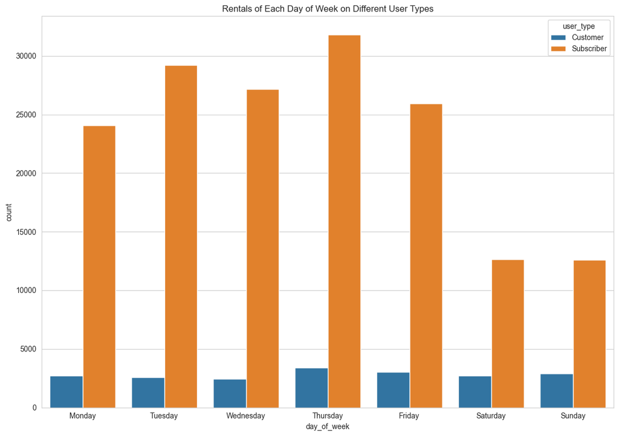

```python
def plot_daily_rentals_by_user_type(df, day_of_week_column, user_type_column, figsize=(11.69, 8.27)):
    sns.set_style("whitegrid")
    fig, ax = plt.subplots(figsize=figsize)

    # Create a countplot of rentals for each day of the week, separated by user type
    order = ['Monday', 'Tuesday', 'Wednesday', 'Thursday', 'Friday', 'Saturday', 'Sunday']
    ax = sns.countplot(x=day_of_week_column, hue=user_type_column, data=df, order=order)

    # Set the title
    ax.set_title('Rentals of Each Day of Week on Different User Types')
    plt.tight_layout()
    plt.show()

plot_daily_rentals_by_user_type(df, 'day_of_week', 'user_type')
```

## Average Trip Duration and Distance by day of month

On weekdays, the average trip distance ranges from 1.7 to 1.8 km, exceeding that of weekends (1.6 to 1.7 km). However, the pattern is reversed for trip duration. On weekdays, users embark on shorter trips lasting 10 to 12 minutes, while on weekends, the average duration extends to 13 to 18 minutes.

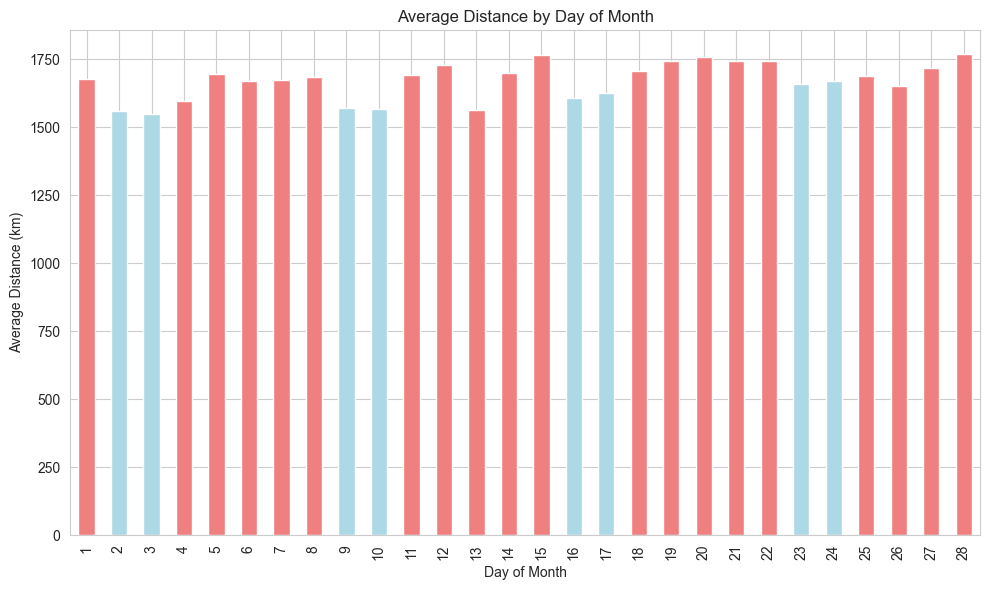

```python
weekend_days = [2, 3, 9, 10, 16, 17, 23, 24]

def plot_avg_distance_by_day(df, groupby_column, value_column, title, xlabel, ylabel, weekday_color, weekend_color, figsize=(10, 6)):
    df_avg_distance = df.groupby(groupby_column)[value_column].mean()

    # Create a color list with different colors for weekdays and weekends
    colors = [weekend_color if day in weekend_days else weekday_color for day in df_avg_distance.index]

    df_avg_distance.plot.bar(figsize=figsize, color=colors)
    plt.title(title)
    plt.xlabel(xlabel)
    plt.ylabel(ylabel)
    plt.tight_layout()
    plt.show()

plot_avg_distance_by_day(df, 'day_of_month', 'distance', 'Average Distance by Day of Month', 'Day of Month', 'Average Distance (km)', 'lightcoral', 'lightblue')
```

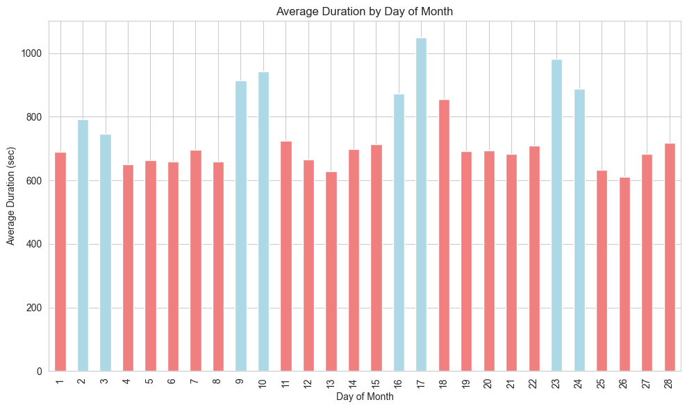

```python
def plot_avg_duration_by_day(df, groupby_column, value_column, title, xlabel, ylabel, weekday_color, weekend_color, figsize=(10, 6)):
    df_avg_distance = df.groupby(groupby_column)[value_column].mean()

     # Create a color list with different colors for weekdays and weekends
    colors = [weekend_color if day in weekend_days else weekday_color for day in df_avg_distance.index]

    df_avg_distance.plot.bar(figsize=figsize, color=colors)
    plt.title(title)
    plt.xlabel(xlabel)
    plt.ylabel(ylabel)
    plt.tight_layout()
    plt.show()

plot_avg_duration_by_day(df, 'day_of_month', 'duration_sec', 'Average Duration by Day of Month', 'Day of Month', 'Average Duration (sec)', 'lightcoral', 'lightblue')
```

## Number of Rides during Day of Week per Age Group

On weekdays, the majority of rentals are from individuals aged 30-39, with the 20-29 age group following closely with 2,000-4,000 fewer rides. However, during the weekend, the 20-29 age group becomes the primary renters, leading the 30-39 group by only a few hundred rides.

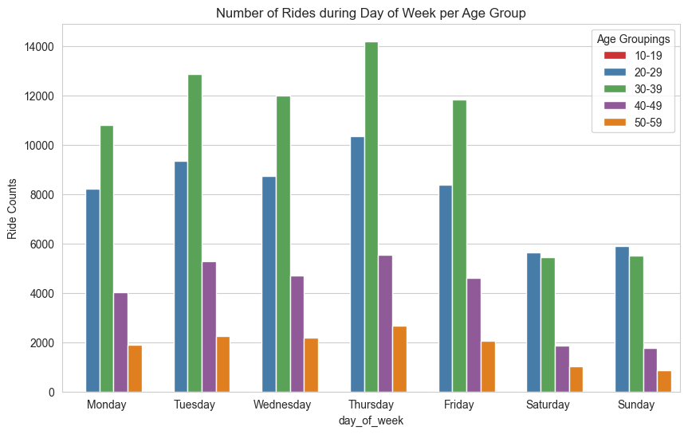

```python
def plot_ride_counts_by_age_group(df, age_group_column, day_of_week_column, age_groups, days_of_week, figsize=(10, 6)):
    # Filter DataFrame for desired age groups
    df_filtered = df.loc[df[age_group_column].isin(age_groups)]

    # Create plot
    plt.figure(figsize=figsize)
    ax = sns.countplot(data=df_filtered, x=day_of_week_column, hue=age_group_column, order=days_of_week, palette='Set1', hue_order=age_groups)
    plt.title('Number of Rides during Day of Week per Age Group')
    plt.legend(title='Age Groupings', loc='upper right')
    plt.ylabel('Ride Counts')
    plt.show()

plot_ride_counts_by_age_group(df, 'age_group', 'day_of_week',
                              ['10-19', '20-29', '30-39', '40-49', '50-59'],
                              ['Monday','Tuesday','Wednesday','Thursday','Friday','Saturday','Sunday'])
```

## Average Ride Duration and Distance by Region

In San Francisco, there were 133,708 rentals, 41,434 in Oakland, and 8,073 in San Jose. The average ride duration across the regions peaks around noon, with San Francisco riders taking the longest trips (over 10 minutes), followed by Oakland (~9.2 min) and San Jose (~8.3 min).

Similarly, the average ride distance shows a rush-hour pattern, with peaks at around 8 am and 5 pm. San Francisco riders cover the longest distance (averaging over 1.5 km), followed by Oakland (~1.4 km) and San Jose (~1.2 km). This aligns with expectations based on city size and population.

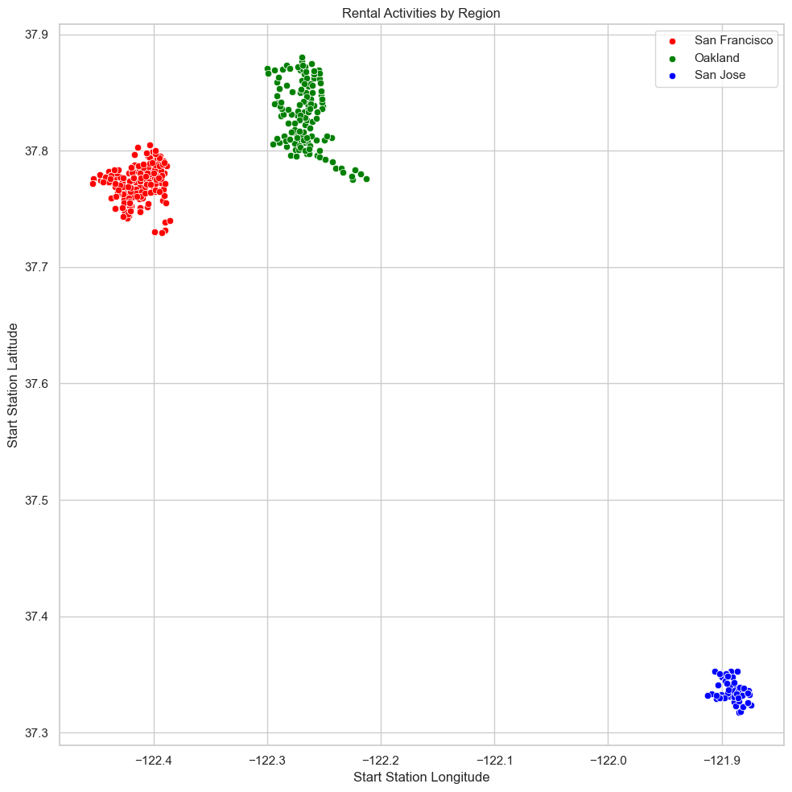

```python
def plot_station_coordinates_by_region(df, latitude_column, longitude_column, region_column, regions, colors, figsize=(10, 10)):
    with sns.plotting_context("notebook"):
        # Create a matplotlib figure
        fig, ax = plt.subplots(figsize=figsize)

        # Plot the scatterplot of latitude vs longitude for each region
        for region, color in zip(regions, colors):
            sns.scatterplot(y=latitude_column, x=longitude_column,
                            data=df.query(f"{region_column} == '{region}'"),
                            label=region, color=color)

        # Set the title, labels, and legend
        plt.title('Rental Activities by Region')
        plt.ylabel('Start Station Latitude')
        plt.xlabel('Start Station Longitude')
        plt.legend()
        plt.tight_layout()
        plt.show()

plot_station_coordinates_by_region(df, 'start_station_latitude', 'start_station_longitude', 'region',
                                   ['San Francisco', 'Oakland', 'San Jose'], ['r', 'g', 'b'])
```

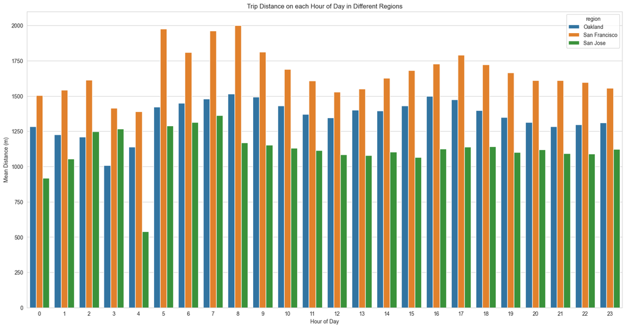

```python
def plot_trip_distance_by_hour(df, hour_column, distance_column, region_column, distance_cutoff, figsize=(20, 10)):
    # Create a matplotlib figure
    fig, ax = plt.subplots(figsize=figsize)

    # Create a barplot of mean distance vs hour for each region
    sns.barplot(x=hour_column, y=distance_column,
                data=df.query(f"{distance_column} < {distance_cutoff}").groupby(
                    [hour_column, region_column], as_index=False)[distance_column].mean(),
                hue=region_column)

    # Set the title
    plt.xlabel('Hour of Day')
    plt.ylabel('Mean Distance (m)')
    plt.title('Trip Distance on each Hour of Day in Different Regions')
    plt.show()


plot_trip_distance_by_hour(df, 'hour', 'distance', 'region', 5070)
```

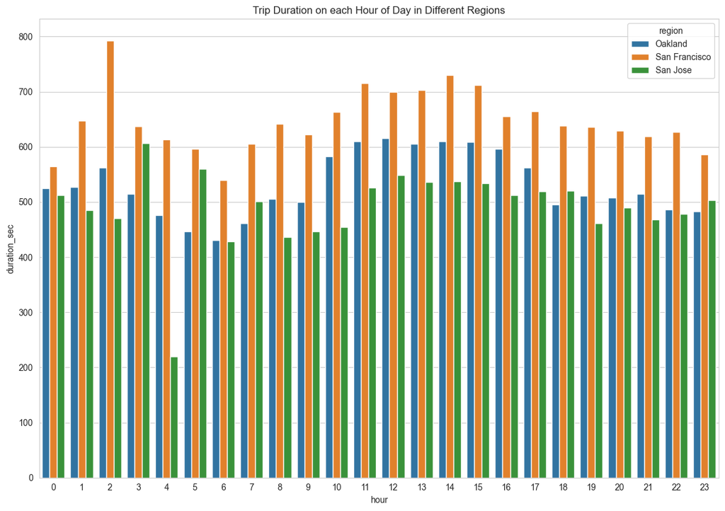

```python
def plot_trip_duration_by_hour(df, hour_column, duration_column, region_column, duration_cutoff, figsize=(11.69, 8.27)):
    sns.set_style("whitegrid")
    fig, ax = plt.subplots(figsize=figsize)

    # Create a barplot of mean duration vs hour for each region
    sns.barplot(x=hour_column, y=duration_column,
                data=df.query(f"{duration_column} < {duration_cutoff}").groupby(
                    [hour_column, region_column], as_index=False)[duration_column].mean(),
                hue=region_column)

    # Set the title
    plt.title('Trip Duration on each Hour of Day in Different Regions')
    plt.tight_layout()
    plt.show()


plot_trip_duration_by_hour(df, 'hour', 'duration_sec', 'region', 3457)
```

```python
# Export notebook to html
!python3 -m nbconvert --to html Part_II_slide_deck_template.ipynb
```

[output not shown]

```python
# Open html file in browser
!open *.html
```